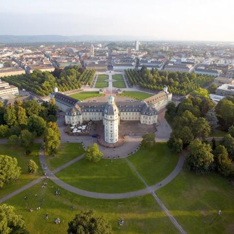

## VL Forschungsmethoden

Grundbegriffe der Messtheorie

Samuel Merk & Cora Parrisius

Sommersemster 2025

## Inhalte dieses Vorlesungsblocks

Was ist eine Messung?

Typologien von Variablen

Gütekriterien einer Messung

Erhebungsverfahren

Dos and Don’ts bei der Fragebogenerstellung

Übung & Anwendung

Was ist eine Messung?

## Messung als Homomorphismus

> Eine Messung („measurement“) meint in der quantitativen Sozialforschung eine Zuordnung von Objekten zu Zahlen, sofern diese Zuordnung eine homomorphe (strukturerhaltende) Abbildung eines empirischen Relativs in ein numerisches Relativ ist (Orth, 1983).

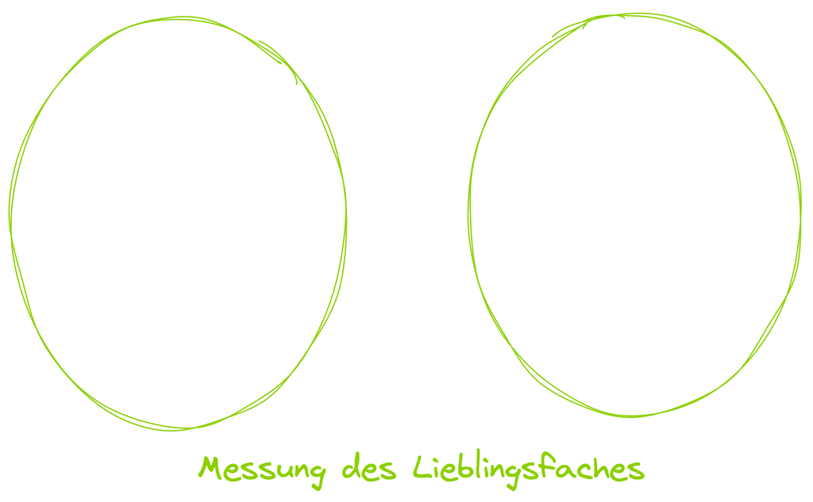

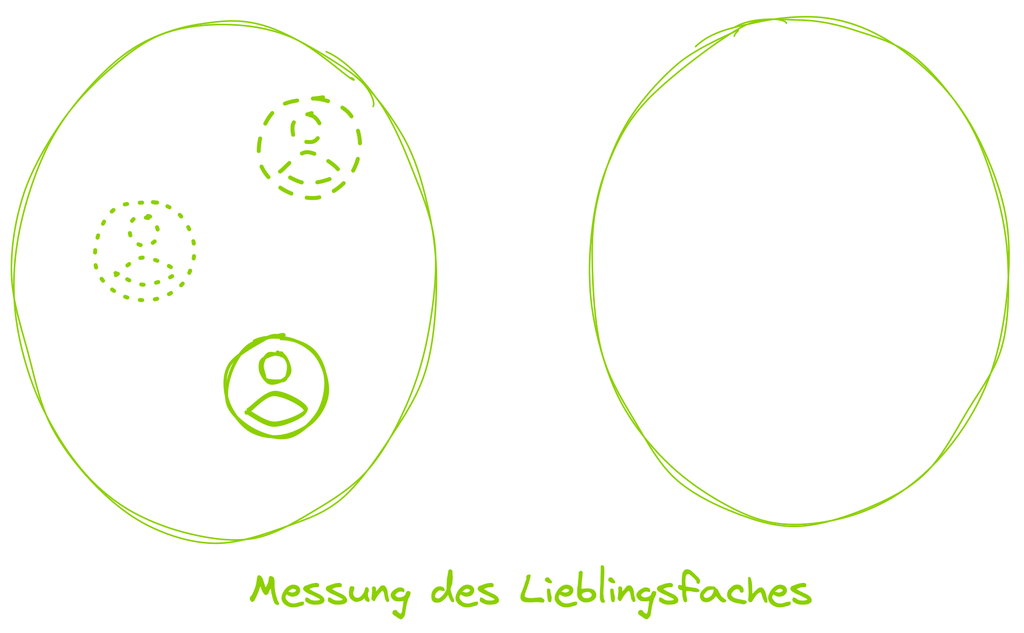

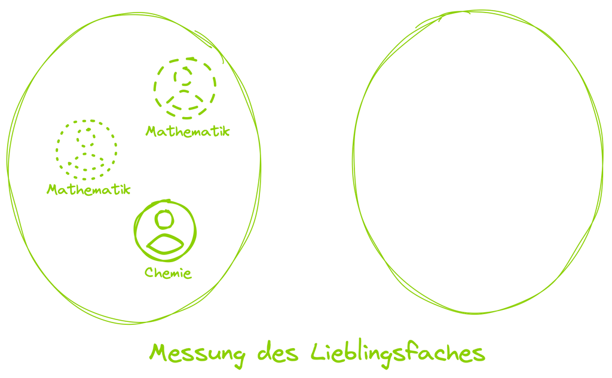

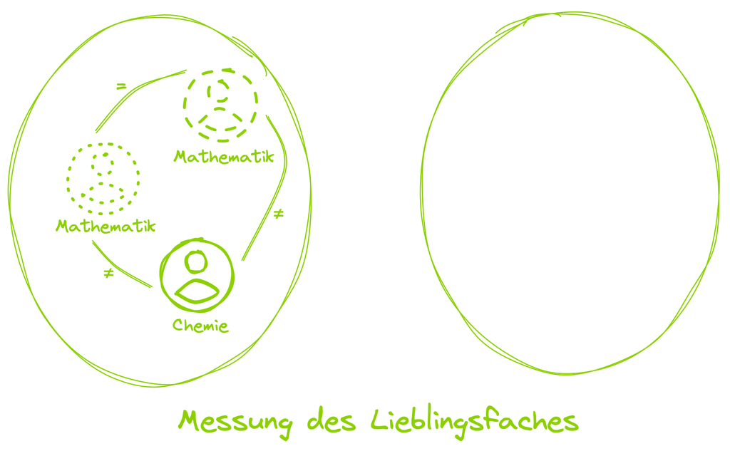

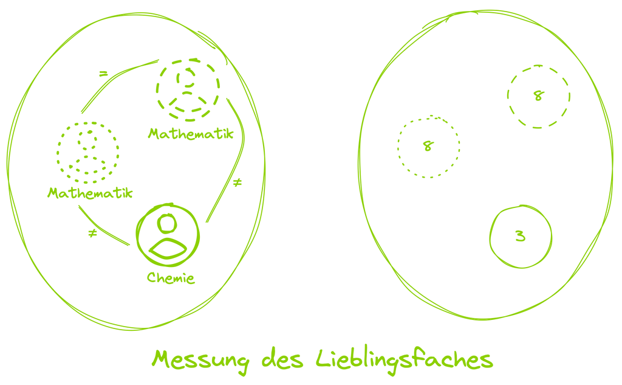

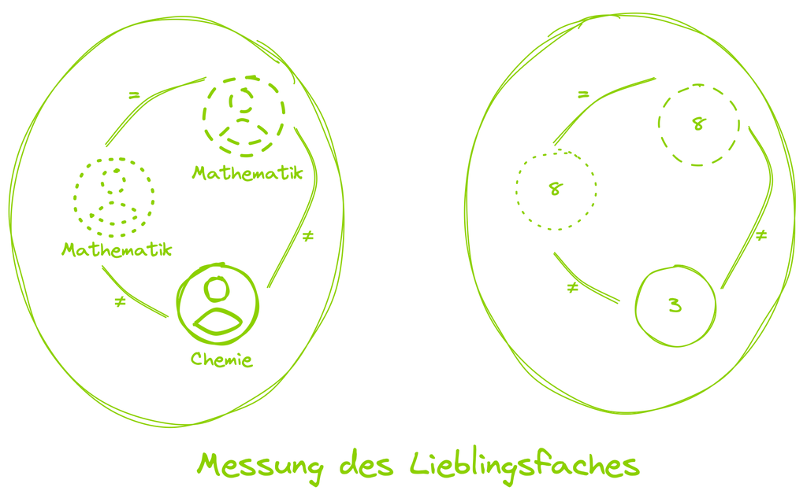

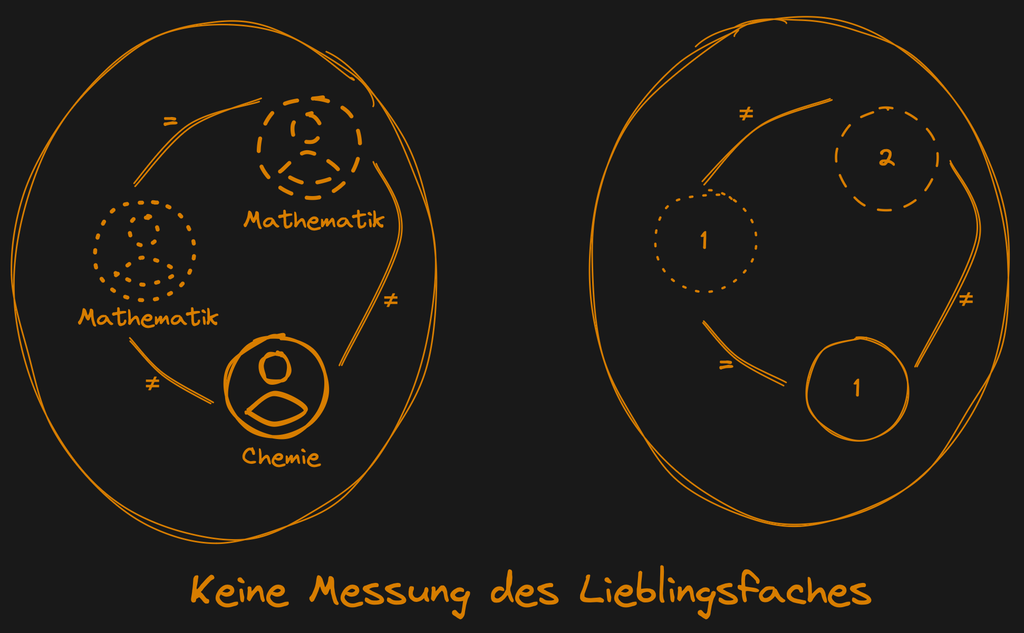

## Messung als Homomorphismus

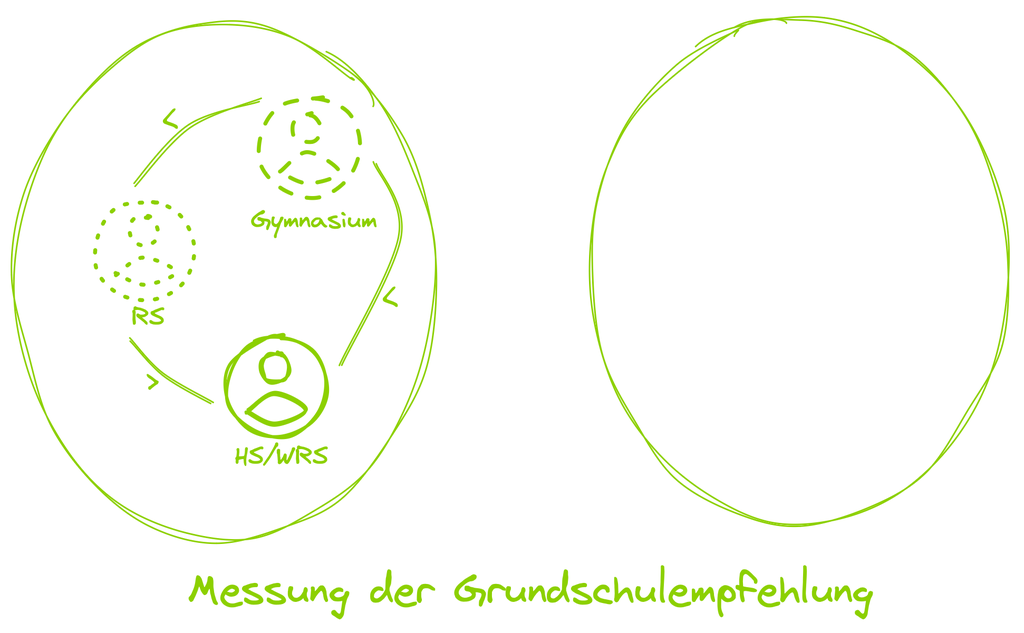

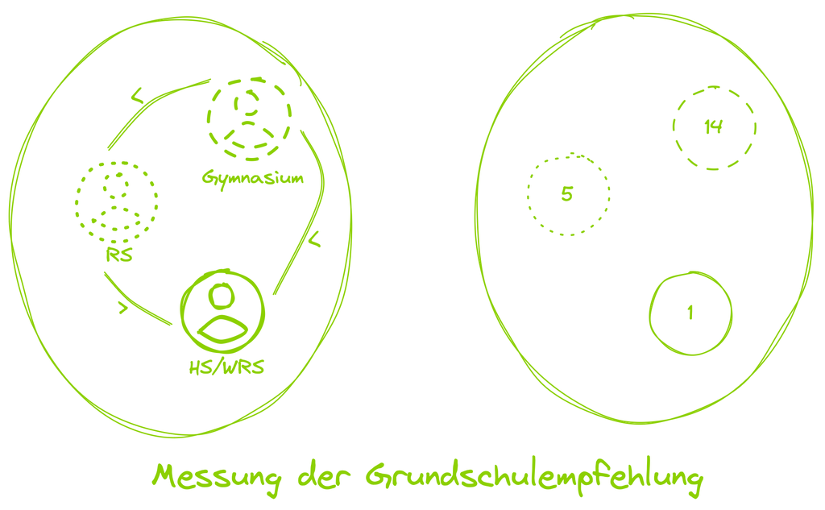

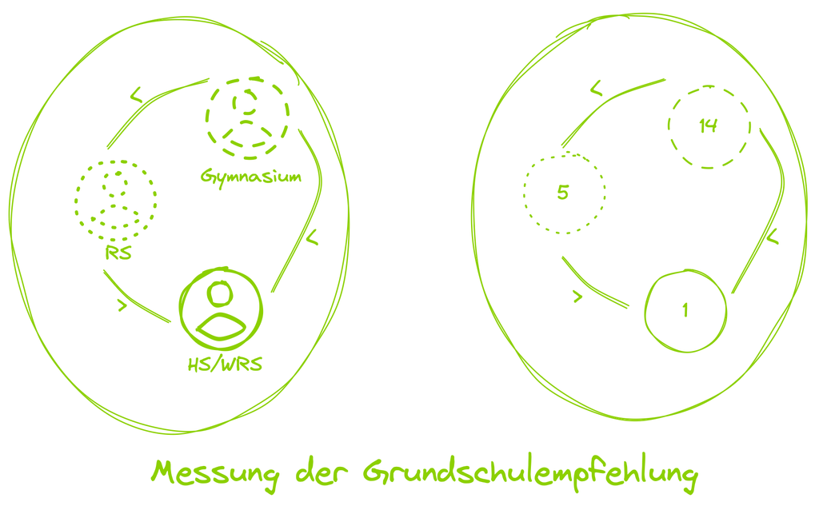

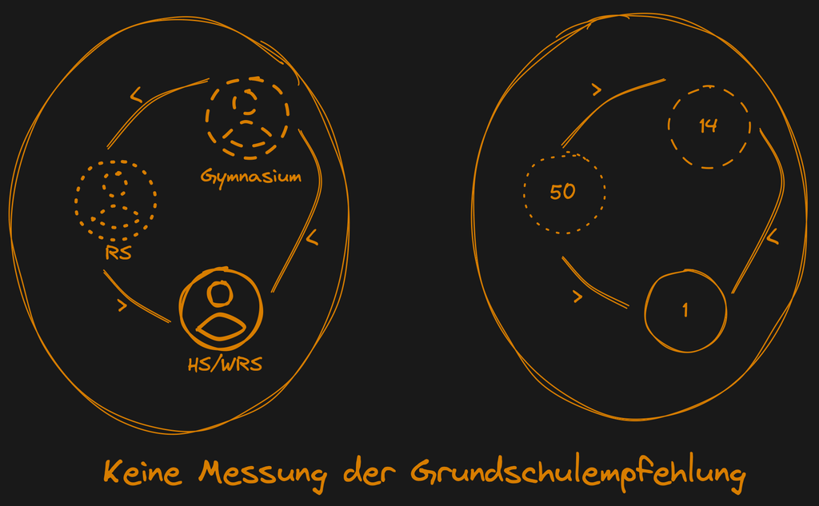

**Weiterführende Literatur**

Eid, M., Gollwitzer, M., & Schmitt, M. (2013). Statistik und Forschungsmethoden: Lehrbuch. Mit Online-Materialien. Beltz. Steyer, R., & Eid, M. (2013). Messen und Testen. Springer-Verlag.

Typologien von Variablen

## Typologie I: Skalenniveaus

> Das Skalenniveau einer Variable beschreibt, welche Relationen im numerischen Relativ sinnvoll sind (Döring & Bortz, 2016).

| Skalenniveau | Sinnvolle Relationen | Beispiel |
| --- | --- | --- |
| Nominalskala | Gleichheit | Lieblingsfach |
| Ordinalskala | Gleichheit + Ordnung | Grundschulempfehlung |
| Intervallskala | Gleichheit + Ordnung + Abstand | tägl. Internetnutzung |

## Aufgabe

[video not shown]

## Typologie II: Inferenzniveau

> Das Inferenzniveau einer Variable beschreibt, in welchem Ausmaß bei einer Messung geschlussfolgert/abstrahiert wird (Lotz, Gabriel, & Lipowsky, 2013). Da Werte im numerischen Relativ immer schlussfolgernd interpretiert werden müssen, macht es mehr Sinn von höh**er**inferenten/niedrig**er**inferenten Variablen zu sprechen als von hochinferenten/niedriginferenten Variablen.

#### Niedrigerinferente Variablen

- Sind mehr oder weniger direkt beobachtbar
- *Beispiel: “Anzahl der Fehltage einer Schülerin”*

#### Hochinferentere Variablen

- Sind nicht direkt beobachtbar
- *Beispiel: “Kognitive Aktivierung”*

## Aufgabe

[video not shown]

## Typologie III: Theo. Kausalzusammenhang

Als **abhängige Variable (AV)** wird eine (kausal) beeinflusste Variable bezeichnet, während die **unabhängige Variable (UV)** die beeinflussende Variable darstellt. Eine **Mediatorvariable (MeV)** ist zugleich AV und UV. Beeinflusst eine Variable eine Wirkung bezeichent man sie als **moderierende Variable (MoV)** (Eid, Gollwitzer, & Schmitt, 2013)

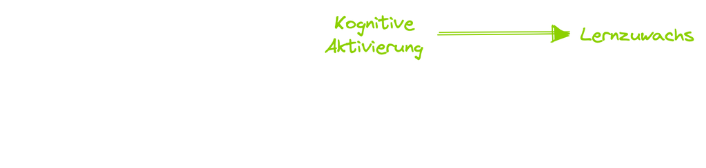

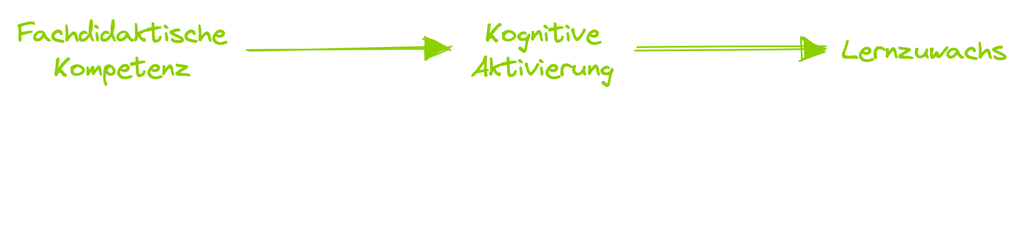

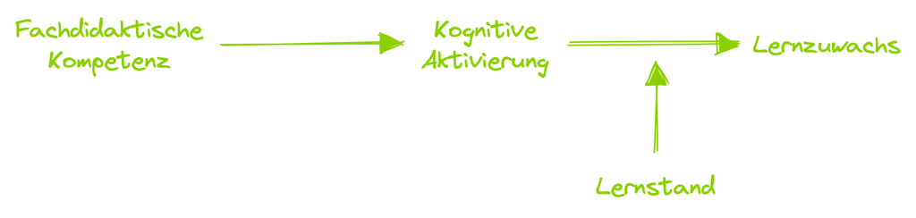

**Weiterführende Literatur**

Pearl, J., Glymour, M., & Jewell, N. P. (2016). Causal inference in statistics: A primer. Wiley.

## Aufgabe

[video not shown]

## Aufgabe

[video not shown]

Gütekriterien einer Messung

## Objektivität

> Zur Beschreibung der Objektivität einer Messung oder eines Tests wird typischerweise zwischen der Durchführungsobjektivität, der Auswertungsobjektivität und der Interpretationsobjektivität differenziert (Döring & Bortz, 2016), also der Unabhängigkeit des Ergebnisses der Messung/des Test von der durchführenden, auswertenden bzw. interpretierenden Person.

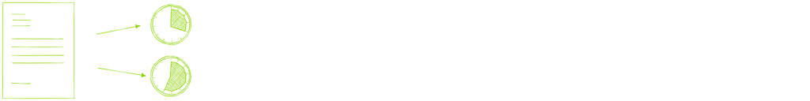

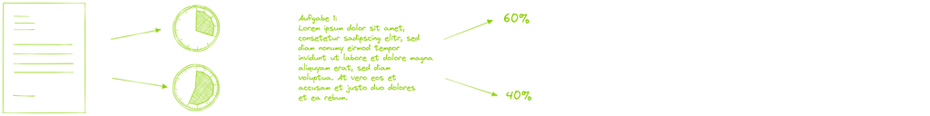

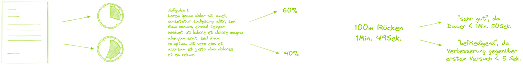

## Reliabilität

> Reliabilität ist Ausmaß an Messfehlerfreiheit

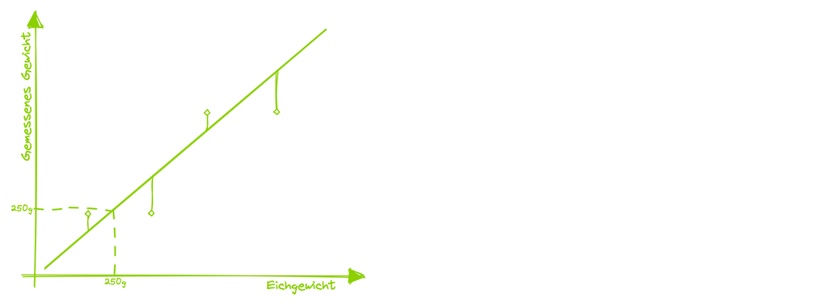

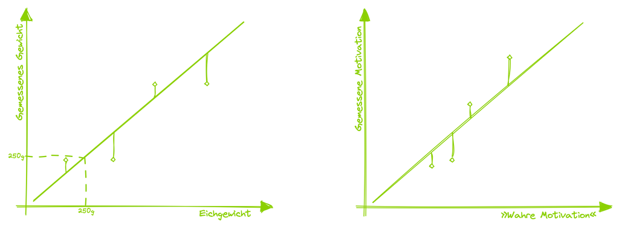

## Validität

#### Kriteriumsvalidität

“Ein Test weist Kriteriumsvalidität auf, wenn vom Verhalten der Testperson innerhalb der Testsituation erfolgreich auf ein »Kriterium«, nämlich auf ein Verhalten außerhalb der Testsituation, geschlossen werden kann” (Moosbrugger & Kelava, 2020).

## Validität

#### Konstruktvalidität

Das Ausmaß der theoretischen und empirischen Belege für die Angemessenheit der Interpretation von Testwerten (Cronbach & Meehl, 1955).

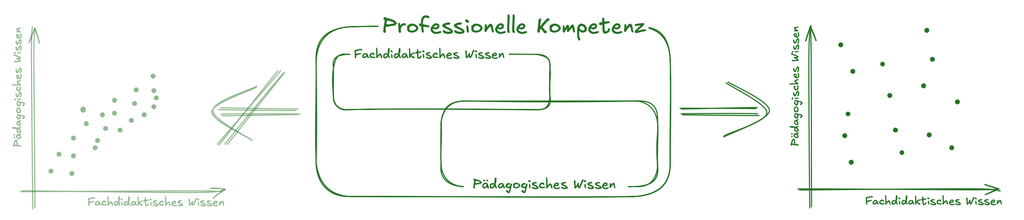

Erhebungsverfahren

## Beobachtung

Wissenschaftliche Beobachtung ist die systematische und regelgeleitete Registrierung des Auftretens und der Ausprägung von ausgewählten, psychologisch relevanten Merkmalen oder Ereignissen. Sie folgt einem zuvor festgelegten Beobachtungsplan, der festlegt, 1) was beobachtet werden soll, 2) welche Aspekte weniger oder nicht relevant sind, 3) welchen Interpretationsspielraum der Beobachtende bei der Beobachtung hat , 4) wann, wie lange und wo die Beobachtung erfolgt und 5) auf welche Weise das Beobachtete registriert und protokolliert wird (Hussy, Schreier, & Echterhoff, 2013).

#### Zentrale Vorteile

- Potentielle Vermeidung von Reaktanz
- Teilw. höhere Reliabilität

#### Zentrale Nachteile

- Oft nicht ökonomisch
- Kognitive und psychische Variablen oft nur schwierig zugänglich

## Selbstauskünfte

Interview, Fragebögen und Tests stellen Beispiele für Selbstauskünfte dar.

#### Zentrale Vorteile

- Kognitive und psychische Variablen zugänglich
- Teilweise sehr ökonomisch

#### Zentrale Nachteile

- Reaktanz oft höher
- Entwicklung von Fragebögen und Tests oft sehr aufwändig

## Physiologische Messung

Beispiele für physiologische Messungen im bildungswissenschaftlichen Bereich stellen die Messung der Hautleitfähigkeit und der Blickbewegungen dar.

#### Zentrale Vorteile

- Teilweise nur schwer verfälschbar
- Unbewusste Prozesse werden zugänglich

#### Zentrale Nachteile

- Meist nicht verdeckt durchführbar
- Oft Laborbedingungen erforderlich

## Dokumentenanalyse

Bei der Dokumentenanalyse werden bereits existierende schriftliche Artefakte untersucht (z.B. Schriftliche Leitbilder, Klassentagebücher, Schriftwechsel, Homepages). Diese können sowohl in hoch- wie niedrig strukturierten Prozessen gesammelt, transformiert und analysiert werden (qualitative und quantitative Dokumentenanalyse).

#### Zentrale Vorteile

- Keine Genese von Daten notwendig
- Teilweise sehr ökonomisch

#### Zentrale Nachteile

- Beschränkte Auswahl an Variablen
- Artefakte müssen präexistieren

Dos and Don’ts bei der Fragebogenerstellung

## Fragebogendesign: Begriffe

- Item = Einzelfrage
- Skala = Mehrere Items, die Operationalisierungen einer Variablen darstellen
- Rating-Item = Item, das intervallskaliert ist
- Likert-Item = Item, deren Stamm eine Aussage darstellt und deren Antwortmöglichkeit die abgestufte Zustimmung zu dieser Aussage enthält
- Offenes Item = Item, bei dem die Antwortmöglichkeiten nicht vorgegeben sind

## Fragebogendesign: Faustregeln

- Verwenden Sie nach Möglichkeit unbedingt etablierte (also von Wissenschaftler*innen validierte) Items und Skalen. Dies wird umso wichtiger je höherinferent Ihre Variable ist.
- Formulieren Sie Items so, dass Sie ein möglichst hohes Skalenniveau erhalten (statt »Rauchen Sie?«, »Wie viele Zigaretten rauchen Sie durchschnittlich pro Tag?«)
- Vermeiden Sie mehrdimensionale Interpretationsmöglichkeiten (typisch bei und/oder Verknüpfungen z.B. »Ich fahre sehr gerne und sehr schnell Auto«)
- Vermeiden Sie (doppelte) Verneinungen (z.B. »Ich bin nicht oft unglücklich«)
- Planen Sie für jedes Item eine Auswertungsstrategie **bevor** Sie die Daten erheben.

## Übung

Bearbeiten Sie die folgenden Impulsfragen mit Ihrer Sitznachbarin bzw. Ihrem Sitznachbarn:

- Worin unterscheiden sich Konstruktvalidität und interne Validität?
- Ist ein Instrument, das hochgradig konstruktvalide ist, immer auch hochgradig reliabel?
- Sie wollen in Ihrer Bachelorarbeit den Effekt eines AI-basierten Lautlesetutors untersuchen. Wie gehen Sie vor, um ein Instrument zur Messung der Leseflüssigkeit und Lesekorrektheit zu finden?

## Bezugsnormen in der Praxis

Neben der **Messung** schulischer Fähigkeiten stellt die **Bewertung** selbiger eine zentrale Herausforderung für LuL dar (Bohl, 2004). Grundsätzlich wird dabei zwischen **formativem** und **summativem** Assessment unterschieden. Bei ersterem dient die Leistungsmessung der Ermittlung des Unterschieds zwischen Lernstand und Lernziel und der dadurch notwendigen nächsten Lernschritte (Schütze, Souvignier, & Hasselhorn, 2018).  
Bei der summativen Leistungsbewertung wird typischerweise zwischen drei Bezugsnormen unterschieden:

[figure not shown]

## Bezugsnormen

Unter Bezugsnormen versteht man den ‚Standard‘, der zur Bewertung einer Leistung herangezogen wird (Heckhausen, 1974).

- Die **‚soziale Bezugsnorm‘** liegt vor, wenn das zu bewertende Ergebnis mit den Ergebnissen einer Vergleichsgruppe, die denselben Test durchlaufen hat, abgeglichen wird.
- Die **‚kriteriale Bezugnorm‘** (auch ‚sachliche Bezugnorm‘; Rheinberg & Fries, Rheinberg & Fries (2010)) legt a priori inhaltlich fest, was eine ‚gute‘ Leistung auszeichnet.
- Die **‚individuelle Bezugsnorm‘** (auch ‚temporale‘, ‚intraindividuelle‘ oder ‚ipsative Bezugsnorm‘) vergleicht (wie die soziale Bezugsnorm) zur Bewertung einer Leistung diese ebenfalls mit anderen realen (empirisch gemessenen) Leistungen. Allerdings stammen jene Leistungen vom selben Merkmalsträger (Individuum).

## Bezugsnormen

- Die Notenvergabeverordnung Baden-Württemberg impliziert klar die Anwendung der kriterialen Bezugsnorm unter Berücksichtigung der individuellen Bezugsnorm in speziellen Fällen (z.B. Probeversetzung).
- Die Anwendung der individuellen Bezugsnorm gilt jedoch klar als stärker motivations- und lernförderlich (Rheinberg & Fries, 2010)
- Lehrerinnen und Lehrer wenden in der Praxis wohl meist implizit eine Mischung von Bezugsnormen an. Dies senkt die Konstruktvalidität der Leistungsmessung

## Aufgabe

> Bearbeiten Sie mehrere Versionen der **Aufgabe 2.7** unter https://ogy.de/mvl-messtheorie

## Literatur

Bohl, T. (2004). *Prüfen und Bewerten im Offenen Unterricht* (2., erw. Aufl). Weinheim Basel: Beltz.

Cronbach, L. J., & Meehl, P. E. (1955). [Construct Validity in Psychological Tests](https://doi.org/10.1037/h0040957). *Psychological bulletin*, *52*(4), 281.

Döring, N., & Bortz, J. (2016). *Forschungsmethoden und Evaluation in den Sozial- und Humanwissenschaften* (5., vollst). Berlin, Heidelberg: Springer.

Eid, M., Gollwitzer, M., & Schmitt, M. (2013). *Statistik Und Forschungsmethoden: Lehrbuch. Mit Online-Materialien* (Third). Beltz.

Heckhausen, H. (1974). *Leistung Und Chancengleichheit*. Göttingen: Hogrefe.

Hussy, W., Schreier, M., & Echterhoff, G. (2013). *[Forschungsmethoden in Psychologie Und Sozialwissenschaften Für Bachelor](https://doi.org/10.1007/978-3-642-34362-9)*. Berlin, Heidelberg: Springer Berlin Heidelberg.

Lotz, M., Gabriel, K., & Lipowsky, F. (2013). [Niedrig und hoch inferente Verfahren der Unterrichtsbeobachtung. Analysen zu deren gegenseitiger Validierung](https://doi.org/10.25656/01:11942).

Moosbrugger, H., & Kelava, A. (Hrsg.). (2020). *[Testtheorie und Fragebogenkonstruktion](https://doi.org/10.1007/978-3-662-61532-4)*. Berlin, Heidelberg: Springer Berlin Heidelberg.

Orth, B. (1983). Grundlagen Des Messens. In H. Feger & J. Bredenkamkp (Hrsg.), *Enzyklopädie Der Psychologie: Themenbereich B, Serie I Forschungsmethoden Der Psychologie, Bd. 3: Messen Und Testen* (S. 136–180). Göttingen: Hogrefe.

Rheinberg, F., & Fries, S. (2010). Bezugsnormorientierung. In D. H. Rost (Hrsg.), *Handwörterbuch Pädagogische Psychologie* (4. Aufl., S. 61–67). Weinheim: Beltz.

Schütze, B., Souvignier, E., & Hasselhorn, M. (2018). [Stichwort Formatives Assessment](https://doi.org/10.1007/s11618-018-0838-7). *Zeitschrift für Erziehungswissenschaft*, *21*(4), 697–715.